# NumPy

## 홈페이지 -> https://numpy.org/

[figure not shown]

## 넘파이란?

NumPy는 Python의 과학 컴퓨팅을 위한 기본 패키지입니다. 다차원 배열 객체, 다양한 파생 객체(예: 마스크된 배열 및 행렬) 및 수학, 논리, 모양 조작, 정렬, 선택, I/O를 포함한 배열에 대한 빠른 작업을 위한 일련의 루틴을 제공하는 Python 라이브러리입니다. 이산 푸리에 변환, 기본 선형 대수학, 기본 통계 연산, 무작위 시뮬레이션 등.

`이산 푸리에 변환 : 시간 도메인 영역의 함수를 주파수 도메인의 함수로 변환한다.`

NumPy 패키지의 핵심은 ndarray 객체입니다. 이것은 성능을 위해 컴파일된 코드에서 수행되는 많은 작업과 함께 동종 데이터 유형의 n 차원 배열을 캡슐화 합니다. NumPy 배열과 표준 Python 시퀀스 사이에는 몇 가지 중요한 차이점이 있습니다.

- NumPy 배열은 Python 목록(동적으로 커질 수 있음)과 달리 생성 시 고정된 크기를 갖습니다. ndarray 의 크기를 변경하면 새 배열이 생성되고 원본이 삭제됩니다.
- NumPy 배열의 요소는 모두 동일한 데이터 유형이어야 하므로 메모리에서 동일한 크기가 됩니다. 예외: (NumPy를 포함한 Python) 객체의 배열을 가질 수 있으므로 다양한 크기의 요소 배열을 허용합니다.
- NumPy 배열은 많은 수의 데이터에 대한 고급 수학 및 기타 유형의 연산을 용이하게 합니다. 일반적으로 이러한 작업은 Python의 내장 시퀀스를 사용하여 가능한 것보다 더 적은 코드로 더 효율적으로 실행됩니다.
- 점점 더 많은 과학 및 수학 Python 기반 패키지가 NumPy 배열을 사용하고 있습니다. 이들은 일반적으로 Python 시퀀스 입력을 지원하지만 처리 전에 이러한 입력을 NumPy 배열로 변환하고 종종 NumPy 배열을 출력합니다. 다시 말해, 오늘날의 과학/수학 Python 기반 소프트웨어의 많은(아마도 대부분)을 효율적으로 사용하려면 Python의 내장 시퀀스 유형을 사용하는 방법을 아는 것만으로는 충분하지 않습니다. NumPy 배열을 사용하는 방법도 알아야 합니다.

# 배열이란 무엇입니까?

배열은 NumPy 라이브러리의 중심 데이터 구조입니다. 배열은 값의 그리드이며 원시 데이터, 요소를 찾는 방법 및 요소를 해석하는 방법에 대한 정보를 포함합니다. 다양한 방법 으로 인덱싱할 수 있는 요소 그리드가 있습니다 . 요소는 모두 배열 이라고 하는 동일한 유형 dtype입니다.

배열은 음이 아닌 정수 튜플, 부울, 다른 배열 또는 정수로 인덱싱될 수 있습니다. rank배열의 차원 수이다. shape배열의 각 차원에 따른 배열의 크기를주는 정수 튜플이다.

NumPy 배열을 초기화할 수 있는 한 가지 방법은 2차원 이상의 데이터에 대해 중첩 목록을 사용하여 Python 목록에서 가져오는 것입니다.

예를 들어:

a = np.array([1, 2, 3, 4, 5, 6])

또는:

a = np.array([[1, 2, 3, 4], [5, 6, 7, 8], [9, 10, 11, 12]])

```python
a = np.array([[1, 2, 3, 4], [5, 6, 7, 8], [9, 10, 11, 12]])
```

대괄호를 사용하여 배열의 요소에 액세스할 수 있습니다. 요소에 액세스할 때 NumPy의 인덱싱은 0에서 시작한다는 것을 기억하십시오.

즉, 배열의 첫 번째 요소에 액세스하려는 경우 요소 "0"에 액세스하게 됩니다.

```python
print(a[0])
```

```
[1 2 3 4]
```

# 배열

"N차원 배열"의 줄임말인 "ndarray"라는 배열을 종종 들을 수 있습니다.

N차원 배열은 단순히 차원 수에 관계없이 배열입니다.

당신은 또한들을 수있는 1-D , 또는 1 차원 배열, 2-D 등, 또는 2 차원 배열하고있다. NumPy ndarray클래스는 행렬과 벡터를 모두 나타내는 데 사용됩니다.

벡터 동안, 단일 차원 (행과 열 벡터 사이의 차이가 없다)를 갖는 배열 행렬은 두 개의 차원으로 배열을 말한다.

예를 들면 3 차원 이상의 고차원 배열 용어 텐서는 또한 일반적으로 사용된다.

# NumPy 배열

많은 숫자 데이터를 하나의 변수에 넣고 관리 할 때 리스트는 속도가 느리고 메모리를 많이 차지하는 단점이 있다.

**배열(array)**을 사용하면 적은 메모리로 데이터를 빠르게 처리할 수 있다. 배열은 리스트와 비슷하지만 다음과 같은 점에서 다르다.

1. 모든 원소가 같은 자료형이어야 한다.
2. 원소의 갯수를 바꿀 수 없다.

파이썬은 자체적으로 배열 자료형을 제공하지 않는다. 따라서 배열을 구현한 다른 패키지를 임포트해야 한다. 파이썬에서 배열을 사용하기 위한 표준 패키지는 NumPy(보통 "넘파이"라고 발음한다)이다.

NumPy는 수치해석용 파이썬 패키지이다. 다차원의 배열 자료구조 클래스인 ndarray 클래스를 지원하며 벡터와 행렬을 사용하는 선형대수 계산에 주로 사용된다. 내부적으로는 BLAS 라이브러리와 LAPACK 라이브러리를 사용하고 있으며 C로 구현된 CPython에서만 사용할 수 있다.

NumPy의 배열 연산은 C로 구현된 내부 반복문을 사용하기 때문에 파이썬 반복문에 비해 속도가 빠르며 **벡터화 연산(vectorized operation)**을 이용하여 간단한 코드로도 복잡한 선형 대수 연산을 수행할 수 있다. 또한 **배열 인덱싱(array indexing)**을 사용한 질의(Query) 기능을 이용하여 간단한 코드로도 복잡한 수식을 계산할 수 있다.

## NumPy 패키지 임포트

배열을 사용하기 위해서는 우선 다음과 같이 NumPy 패키지를 임포트한다. NumPy는 np라는 이름으로 임포트하는 것이 관례이다.

```python
import numpy as np
```

## 1차원 배열 만들기

NumPy의 `array`라는 함수에 리스트를 넣으면 배열로 변환해 준다. 따라서 1 차원 배열을 만드는 방법은 다음과 같다.

```python
ar = np.array([0, 1, 2, 3, 4, 5, 6, 7, 8, 9])
ar
```

```
array([0, 1, 2, 3, 4, 5, 6, 7, 8, 9])
```

리스트와 비슷해 보이지만 `type` 명령으로 자료형을 살펴보면 ndarray임을 알 수 있다.

`ndarray` 는 N-dimensional Array의 약자이다.

```python
type(ar)
```

```
numpy.ndarray
```

만들어진 `ndarray` 객체의 표현식(representation)을 보면 바깥쪽에 array()란 것이 붙어 있을 뿐 리스트와 동일한 구조처럼 보인다. 그러나 배열 객체와 리스트 객체는 많은 차이가 있다.

**우선 리스트 클래스 객체는 각각의 원소가 다른 자료형이 될 수 있다.**

`그러나 배열 객체 객체는 C언어의 배열처럼 연속적인 메모리 배치를 가지기 때문에 모든 원소가 같은 자료형이어야 한다.` 이러한 제약사항이 있는 대신 원소에 대한 접근과 반복문 실행이 빨라진다.

```python
import numpy as np

a = np.array([1, 2, 3])
```

다음과 같이 배열을 시각화할 수 있습니다.

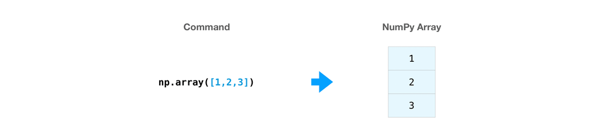

```python
# 요소 시퀀스에서 배열을 만드는 것 외에도 0'로 채워진 배열을 쉽게 만들 수 있습니다 .

np.zeros(2)
```

```
array([0., 0.])
```

```python
# 또는 로 채워진 배열 1:

np.ones(2)
```

```
array([1., 1.])
```

```python
# 또는 빈 배열일 수도 있습니다! 이 함수 empty는 초기 내용이 무작위이고 메모리 상태에 따라 달라지는 배열을 만듭니다.
# emptyover zeros(또는 이와 유사한 것) 를 사용하는 이유 는 속도입니다. 나중에 모든 요소를 채우십시오!

np.empty(2)
```

```
array([1., 1.])
```

```python
# 요소 범위가 있는 배열을 만들 수 있습니다.

np.arange(4)
```

```
array([0, 1, 2, 3])
```

```python
# 균등한 간격의 범위를 포함하는 배열도 있습니다.
# 이렇게 하려면 첫 번째 숫자 , 마지막 숫자 및 단계 크기를 지정 합니다.

np.arange(2, 9, 2)
```

```
array([2, 4, 6, 8])
```

```python
# np.linspace()하여 지정된 간격으로 선형으로 간격을 둔 값으로 배열을 생성 할 수 있습니다 .

np.linspace(0, 10, num=5)
```

```
array([ 0. ,  2.5,  5. ,  7.5, 10. ])
```

### 데이터 유형 지정

기본 데이터 유형은 부동 소수점( np.float64)이지만 dtype키워드를 사용하여 원하는 데이터 유형을 명시적으로 지정할 수 있습니다 .

```python
x = np.ones(2, dtype=np.int64)
x
```

```
array([1, 1], dtype=int64)
```

### 요소 추가, 제거 및 정렬

```python
# np.sort(). 함수를 호출할 때 축, 종류, 순서를 지정할 수 있습니다.

arr = np.array([2, 1, 5, 3, 7, 4, 6, 8])
```

```python
np.sort(arr)
```

```
array([1, 2, 3, 4, 5, 6, 7, 8])
```

### 배열의 정렬된 복사본을 반환하는 정렬 외에도 다음을 사용할 수 있습니다.

- argsort : 지정된 축을 따른 간접 정렬,
- lexsort : 여러 키에 대한 간접적인 안정적인 정렬입니다.
- searchsorted : 정렬된 배열에서 요소를 찾습니다.
- partition : 이는 부분 정렬입니다.

```python
# 다음 배열로 시작하는 경우:

a = np.array([1, 2, 3, 4])
b = np.array([5, 6, 7, 8])
```

```python
# np.concatenate() 연결할 수 있습니다

np.concatenate((a, b))
```

```
array([1, 2, 3, 4, 5, 6, 7, 8])
```

```python
# 다음 배열로 시작하는 경우:

x = np.array([[1, 2], [3, 4]])
y = np.array([[5, 6]])
```

```python
np.concatenate((x, y), axis=0)
```

```
array([[1, 2],
       [3, 4],
       [5, 6]])
```

## 벡터화 연산

배열 객체는 배열의 각 원소에 대한 반복 연산을 하나의 명령어로 처리하는 **벡터화 연산(vectorized operation)**을 지원한다.

예를 들어 다음처럼 여러개의 데이터를 모두 2배 해야 하는 경우를 생각하자.

```python
data = [0, 1, 2, 3, 4, 5, 6, 7, 8, 9]
```

for 반복문을 사용하면 다음과 같이 구현할 수 있다.

```python
answer = []

for di in data:
    answer.append(2 * di)
answer
```

```
[0, 2, 4, 6, 8, 10, 12, 14, 16, 18]
```

하지만 벡터화 연산을 사용하면 다음과 같이 for 반복문이 없이 한번의 연산으로 할 수 있다. 계산 속도도 반복문을 사용할 때 보다 훨씬 빠르다.

```python
x = np.array(data)
x
```

```
array([0, 1, 2, 3, 4, 5, 6, 7, 8, 9])
```

```python
2 * x
```

```
array([ 0,  2,  4,  6,  8, 10, 12, 14, 16, 18])
```

참고로 일반적인 리스트 객체에 정수를 곱하면 객체의 크기가 정수배 만큼으로 증가한다.(반복출력)

```python
L = [0, 1, 2, 3, 4, 5, 6, 7, 8, 9]
print(2 * L)
```

```
[0, 1, 2, 3, 4, 5, 6, 7, 8, 9, 0, 1, 2, 3, 4, 5, 6, 7, 8, 9]
```

벡터화 연산은 비교 연산과 논리 연산을 포함한 모든 종류의 수학 연산에 대해 적용된다. 선형 대수에 적용되는 벡터화 연산에 대해서는 나중에 보다 자세히 설명한다.

```python
a = np.array([1, 2, 3])
b = np.array([10, 20, 30])
```

```python
2 * a + b
```

```
array([12, 24, 36])
```

```python
a == 2
```

```
array([False,  True, False])
```

```python
b > 10
```

```
array([False,  True,  True])
```

```python
(a == 2) & (b > 10)
```

```
array([False,  True, False])
```

## 2차원 배열 만들기

`ndarray` 는 N-dimensional Array의 약자이다.

이름 그대로 1차원 배열 이외에도 2차원 배열, 3차원 배열 등의 다차원 배열 자료 구조를 지원한다.

2차원 배열은 **행렬(matrix)**이라고 하는데 행렬에서는 가로줄을 **행**(row)이라고 하고 세로줄을 **열**(column)이라고 부른다.

다음과 같이 리스트의 리스트(list of list)를 이용하면 2차원 배열을 생성할 수 있다. 안쪽 리스트의 길이는 행렬의 열의 수 즉, 가로 크기가 되고 바깥쪽 리스트의 길이는 행렬의 행의 수, 즉 세로 크기가 된다. 예를 들어 2 x 3 배열은 다음과 같이 만든다.

```python
c = np.array([[0, 1, 2], [3, 4, 5]])  # 2 x 3 array
c
```

```
array([[0, 1, 2],
       [3, 4, 5]])
```

2차원 배열의 행과 열의 갯수는 다음처럼 구한다.

```python
# 행의 갯수
len(c)
```

```
2
```

```python
# 열의 갯수
len(c[0])
```

```
3
```

#### 연습 문제

NumPy를 사용하여 다음과 같은 행렬을 만든다.

```
10 20 30 40
50 60 70 80
```

## 3차원 배열 만들기

리스트의 리스트의 리스트를 이용하면 3차원 배열도 생성할 수 있다.

크기를 나타낼 때는 가장 **바깥쪽 리스트의 길이부터 가장 안쪽 리스트 길이의 순서로** 표시한다.

예를 들어 2 x 3 x 4 배열은 다음과 같이 만든다.

```python
d = np.array([[[1, 2, 3, 4],
               [5, 6, 7, 8],
               [9, 10, 11, 12]],
              [[11, 12, 13, 14],
               [15, 16, 17, 18],
               [19, 20, 21, 22]]])   # 2 x 3 x 4 array
```

3차원 배열의 행, 열, 깊이는 다음과 같이 구할 수 있다.

```python
len(d), len(d[0]), len(d[0][0])
```

```
(2, 3, 4)
```

## 배열의 차원과 크기 알아내기

##### ndarray.ndim 배열의 축 또는 차원 수를 알려줍니다.

#### ndarray.size배열의 총 요소 수를 알려줍니다. 이것은 배열 모양 요소의 곱 입니다.

#### ndarray.shape배열의 각 차원을 따라 저장된 요소 수를 나타내는 정수 튜플을 표시합니다.

- 예를 들어 2개의 행과 3개의 열이 있는 2차원 배열이 있는 경우 배열의 모양은 입니다 .(2, 3)

```python
# 예를 들어 다음 배열을 생성하는 경우:

array_example = np.array([[[0, 1, 2, 3],
                            [4, 5, 6, 7]],

                           [[0, 1, 2, 3],
                            [4, 5, 6, 7]],

                           [[0 ,1 ,2, 3],
                           [4, 5, 6, 7]]])
```

```python
# 배열의 차원 수를 찾으려면 다음을 실행하십시오.

array_example.ndim
```

```
3
```

```python
# 배열의 총 요소 수를 찾으려면 다음을 실행하십시오.

array_example.size
```

```
24
```

```python
# 배열의 모양을 찾으려면 다음을 실행하십시오

array_example.shape
```

```
(3, 2, 4)
```

배열의 차원 및 크기를 구하는 더 간단한 방법은 배열의 `ndim` 속성과 `shape` 속성을 이용하는 것이다.

`ndim` 속성은 배열의 차원, `shape` 속성은 배열의 크기를 반환한다.

```python
# a = np.array([1, 2, 3])
print(a.ndim)
print(a.shape)
```

```
1
(3,)
```

```python
# c = np.array([[0, 1, 2], [3, 4, 5]])
print(c.ndim)
print(c.shape)
```

```
2
(2, 3)
```

```python
print(d.ndim)
print(d.shape)
```

```
3
(2, 3, 4)
```

## 배열의 인덱싱

파이썬 목록을 슬라이싱하는 것과 같은 방식으로 NumPy 배열을 인덱싱하고 슬라이싱할 수 있습니다.

```python
data = np.array([1, 2, 3])
```

```python
data[1]
```

```
2
```

```python
data[0:2]
```

```
array([1, 2])
```

```python
data[1:]
```

```
array([2, 3])
```

```python
data[-2:]
```

```
array([2, 3])
```

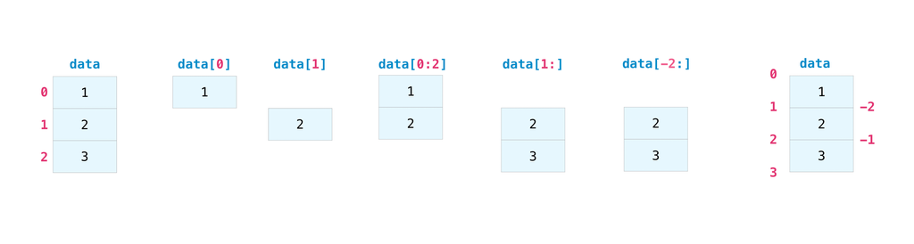

일차원 배열의 인덱싱은 리스트의 인덱싱과 같다.

```python
a = np.array([0, 1, 2, 3, 4])
```

```python
a[2]
```

```
2
```

```python
a[-1]
```

```
4
```

다차원 배열일 때는 다음과 같이 콤마(comma ,)를 사용하여 접근할 수 있다.

- 콤마로 구분된 차원을 축(axis)이라고도 한다. 그래프의 x축과 y축을 떠올리면 될 것이다.

```python
a = np.array([[0, 1, 2], [3, 4, 5]])
a
```

```
array([[0, 1, 2],
       [3, 4, 5]])
```

```python
a[0, 0]  # 첫번째 행의 첫번째 열
```

```
0
```

```python
a[0, 1]  # 첫번째 행의 두번째 열
```

```
1
```

```python
a[-1, -1]  # 마지막 행의 마지막 열
```

```
5
```

## 배열 슬라이싱

배열 객체로 구현한 다차원 배열의 원소 중 복수 개를 접근하려면 일반적인 파이썬 슬라이싱(slicing)과 comma( , )를 함께 사용하면 된다.

```python
a = np.array([[0, 1, 2, 3], [4, 5, 6, 7]])
a
```

```
array([[0, 1, 2, 3],
       [4, 5, 6, 7]])
```

```python
a[0, :]  # 첫번째 행 전체
```

```
array([0, 1, 2, 3])
```

```python
a[:, 1]  # 두번째 열 전체
```

```
array([1, 5])
```

```python
a[1, 1:]  # 두번째 행의 두번째 열부터 끝열까지
```

```
array([5, 6, 7])
```

```python
a[:2, :2]
```

```
array([[0, 1],
       [4, 5]])
```

# 기존 데이터에서 배열을 만드는 방법

```python
# 다음과 같은 배열이 있다고 가정해 보겠습니다.

a = np.array([1,  2,  3,  4,  5,  6,  7,  8,  9, 10])
```

```python
# 배열을 슬라이스할 위치를 지정하여 언제든지 배열의 섹션에서 새 배열을 생성할 수 있습니다.

arr1 = a[3:8]; arr1
```

```
array([4, 5, 6, 7, 8])
```

```python
# 세로 및 가로로 두 개의 기존 어레이를 쌓을 수도 있습니다.
# 두 개의 배열이 a1있고 a2다음 이 있다고 가정해 보겠습니다.

a1 = np.array([[1, 1], [2, 2]])
a2 = np.array([[3, 3], [4, 4]])
```

```python
# 다음을 사용하여 세로로 쌓을 수 있습니다

np.vstack((a1, a2))
```

```
array([[1, 1],
       [2, 2],
       [3, 3],
       [4, 4]])
```

```python
# 또는 다음을 사용하여 수평으로 쌓습니다

np.hstack((a1, a2))
```

```
array([[1, 1, 3, 3],
       [2, 2, 4, 4]])
```

```python
# 배열을 여러 개의 작은 배열로 분할할 수 있습니다

x = np.arange(1, 25).reshape(2, 12)
x
```

```
array([[ 1,  2,  3,  4,  5,  6,  7,  8,  9, 10, 11, 12],
       [13, 14, 15, 16, 17, 18, 19, 20, 21, 22, 23, 24]])
```

```python
# 이 배열을 3개의 동일한 모양의 배열로 분할하려면 다음을 실행합니다.

np.hsplit(x, 3)
```

```
[array([[ 1,  2,  3,  4],
        [13, 14, 15, 16]]),
 array([[ 5,  6,  7,  8],
        [17, 18, 19, 20]]),
 array([[ 9, 10, 11, 12],
        [21, 22, 23, 24]])]
```

```python
# 세 번째와 네 번째 열 이후에 배열을 분할하려면 다음을 실행합니다.

np.hsplit(x, (3, 4))
```

```
[array([[ 1,  2,  3],
        [13, 14, 15]]),
 array([[ 4],
        [16]]),
 array([[ 5,  6,  7,  8,  9, 10, 11, 12],
        [17, 18, 19, 20, 21, 22, 23, 24]])]
```

#### 연습 문제

다음 행렬과 같은 행렬이 있다.

```
m = np.array([[ 0,  1,  2,  3,  4],
              [ 5,  6,  7,  8,  9],
              [10, 11, 12, 13, 14]])
```

1. 이 행렬에서 값 7 을 인덱싱한다.
2. 이 행렬에서 값 14 을 인덱싱한다.
3. 이 행렬에서 배열 [6, 7] 을 슬라이싱한다.
4. 이 행렬에서 배열 [7, 12] 을 슬라이싱한다.
5. 이 행렬에서 배열 [[3, 4], [8, 9]] 을 슬라이싱한다.

```python
import numpy as np

m = np.array([[ 0,  1,  2,  3,  4],
              [ 5,  6,  7,  8,  9],
              [10, 11, 12, 13, 14]])
```

```python
m[1,2]   # 이 행렬에서 값 7 을 인덱싱한다.
```

```
7
```

```python
m[-1, -1]   # 이 행렬에서 값 14 을 인덱싱한다.   m[2,-1]
```

```
14
```

```python
m[1, 1:3]    # 이 행렬에서 배열 [6, 7] 을 슬라이싱한다.
```

```
array([6, 7])
```

```python
m[1:3, 2] # 이 행렬에서 배열 [7, 12] 을 슬라이싱한다.
```

```
array([ 7, 12])
```

```python
m[:2, 3:]# 이 행렬에서 배열 [[3, 4], [8, 9]] 을 슬라이싱한다.
```

```
array([[3, 4],
       [8, 9]])
```

## 배열 인덱싱

NumPy 배열 객체의 또다른 강력한 기능은 **팬시 인덱싱**(fancy indexing)이라고도 부르는 **배열 인덱싱**(array indexing) 방법이다. 인덱싱이라는 이름이 붙었지만 사실은 데이터베이스의 질의(Query) 기능을 수행한다. 배열 인덱싱에서는 대괄호(Bracket, [])안의 인덱스 정보로 숫자나 슬라이스가 아니라 위치 정보를 나타내는 또 다른 `ndarray` 배열을 받을 수 있다. 여기에서는 이 배열을 편의상 인덱스 배열이라고 부르겠다. 배열 인덱싱의 방식에은 불리안(Boolean) 배열 방식과 정수 배열 방식 두가지가 있다.

먼저 불리안 배열 인덱싱 방식은 인덱스 배열의 원소가 True, False 두 값으로만 구성되며 인덱스 배열의 크기가 원래 ndarray 객체의 크기와 같아야 한다.

예를 들어 다음과 같은 1차원 `ndarray`에서 짝수인 원소만 골라내려면 짝수인 원소에 대응하는 인덱스 값이 True이고 홀수인 원소에 대응하는 인덱스 값이 False인 인덱스 배열을 넣으면 된다.

```python
a = np.array([0, 1, 2, 3, 4, 5, 6, 7, 8, 9])
idx = np.array([True, False, True, False, True,
                False, True, False, True, False])
a[idx]
```

```
array([0, 2, 4, 6, 8])
```

조건문 연산을 사용하면 다음과 같이 간단히 쓸 수 있다.

```python
a % 2
```

```
array([0, 1, 0, 1, 0, 1, 0, 1, 0, 1])
```

```python
a % 2 == 0
```

```
array([ True, False,  True, False,  True, False,  True, False,  True,
       False])
```

```python
a[a % 2 == 0]
```

```
array([0, 2, 4, 6, 8])
```

정수 배열 인덱싱에서는 인덱스 배열의 원소 각각이 원래 `ndarray 객체` 원소 하나를 가리키는 인덱스 정수이여야 한다.

- 예를 들어 1차원 배열에서 홀수번째 원소만 골라내는 것은 다음과 같다

```python
a = np.array([11, 22, 33, 44, 55, 66, 77, 88, 99])
idx = np.array([0, 2, 4, 6, 8])
a[idx]
```

```
array([11, 33, 55, 77, 99])
```

이 때는 배열 인덱스의 크기가 원래의 배열 크기와 달라도 상관없다.

- 같은 원소를 반복해서 가리키는 경우에는 배열 인덱스가 원래의 배열보다 더 커지기도 한다.

```python
a = np.array([11, 22, 33, 44, 55, 66, 77, 88, 99])
idx = np.array([0, 0, 0, 0, 0, 0, 1, 1, 1, 1, 1, 2, 2, 2, 2, 2])
a[idx]
```

```
array([11, 11, 11, 11, 11, 11, 22, 22, 22, 22, 22, 33, 33, 33, 33, 33])
```

배열 인덱싱은 다차원 배열의 각 차원에 대해서도 할 수 있다.

```python
a = np.array([[1, 2, 3, 4], [5, 6, 7, 8], [9, 10, 11, 12]])
a
```

```
array([[ 1,  2,  3,  4],
       [ 5,  6,  7,  8],
       [ 9, 10, 11, 12]])
```

```python
a[:, [True, False, False, True]]
```

```
array([[ 1,  4],
       [ 5,  8],
       [ 9, 12]])
```

```python
a[[2, 0, 1], :]
```

```
array([[ 9, 10, 11, 12],
       [ 1,  2,  3,  4],
       [ 5,  6,  7,  8]])
```

#### 연습 문제 4.1.3

다음 행렬과 같은 배열이 있다.

```
x = np.array([1, 2, 3, 4, 5, 6, 7, 8, 9, 10,
              11, 12, 13, 14, 15, 16, 17, 18, 19, 20])
```

1. 이 배열에서 3의 배수를 찾아라.
2. 이 배열에서 4로 나누면 1이 남는 수를 찾아라.
3. 이 배열에서 3으로 나누면 나누어지고 4로 나누면 1이 남는 수를 찾아라.

```python
x = np.array([1, 2, 3, 4, 5, 6, 7, 8, 9, 10,
              11, 12, 13, 14, 15, 16, 17, 18, 19, 20])
```

```python
# 이 배열에서 3의 배수를 찾아라.

x[x % 3 == 0]
```

```
array([ 3,  6,  9, 12, 15, 18])
```

```python
# 이 배열에서 4로 나누면 1이 남는 수를 찾아라.
x[x % 4 == 1]
```

```
array([ 1,  5,  9, 13, 17])
```

```python
# 이 배열에서 3으로 나누면 나누어지고 4로 나누면 1이 남는 수를 찾아라.

x[(x % 3 == 0) & (x % 4 == 1)]
```

```
array([9])
```